# ETC5521 Assignment 1

# 6 Quest for the Yellow Jersey

## 6.1 Procedure

The purpose of this section is to explore the trends of overall winners. We start by answering the most basic question: “Do overall winners win all stages through the edition?”. Here, we discovered that what some overall winners achieved in the early decades have not been achieved in contemporary editions. For instance, wearing the yellow jersey for all stages in the edition. So, we decided to hone in on the last two decades, 2000 - 2020. We studied how overall winners were ranked in each stage and stage type to examine if these riders specialised in any particular domain such as sprinting or climbing. For this section, we utilised regular expressions to manipulate character strings and relational joins to join data sets with matching observations.

## 6.2 A fallacy: Overall Winners leads all stages

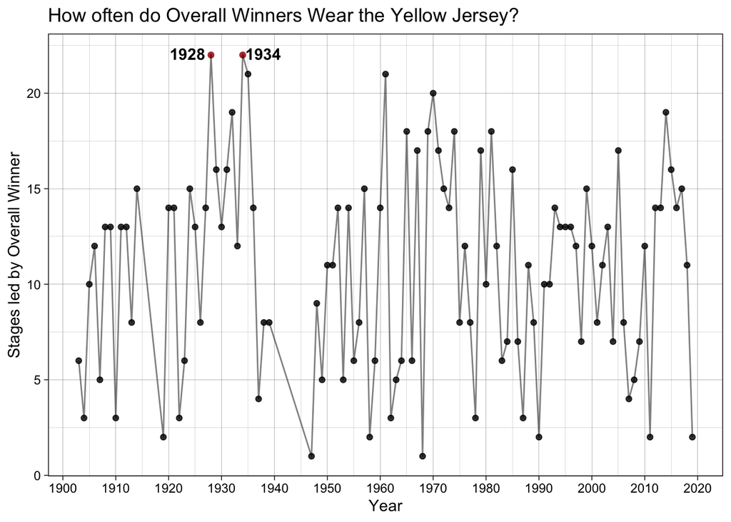

Figure 6.1: How often do Overall Winners Wear the Yellow Jersey

Many speculate that overall winners are cyclists who consistently don the yellow jersey by winning all stages. However, in majority of the editions, the line plot (6.1) invalidates the conjecture, demonstrating that the stage led by overall winners have been shown vary greatly across most editions. The plot further reveals that overall winners can lead as little as 1 stage, suggesting that they only led the tour at the very last stage.

## 6.3 Ranks of Overall Winners in Different Stages

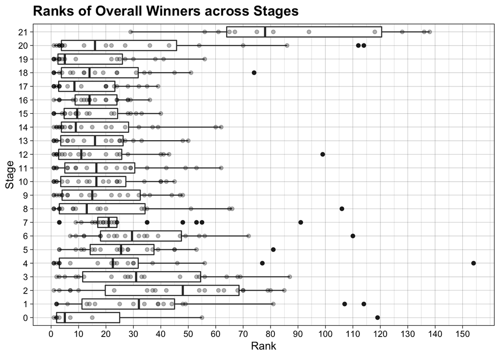

Figure 6.2: Ranks of Overall Winners across Stages (2000 - 2019)

Why are the ranks of overall winners in stage 21 rather high and peculiar? Stage 21, or better known as the “Champs-Élysées” stage, representing a symbolic street in Paris, France. As a tradition, riders set a truce to their competition to have a celebratory moment of tranquillity, chatting and even celebrating with glasses of champagnes in the final kilometres (M (2017)). For this reason, the rankings of overall winners differ greatly in this stage.

## 6.4 Do Overall Winners Thrive in Certain Stage Types or Terrain?

### 6.4.1 Stages of Tour De France

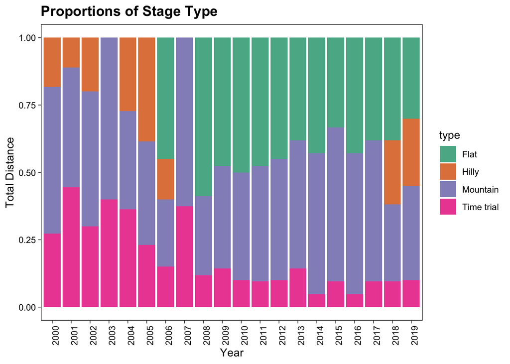

### 6.4.2 Strategies of Overall Winner

Table 6.1: Proportion of Overall Winners Ranked 5th and Below by Stage Type

| Stage Type | Ranked 5th or below | Stage Type Total Count | Proportion |
| --- | --- | --- | --- |
| Flat | 83 | 113 | 73.45% |
| Hilly | 20 | 26 | 76.92% |
| Mountain | 111 | 147 | 75.51% |
| Time trial | 36 | 51 | 70.59% |

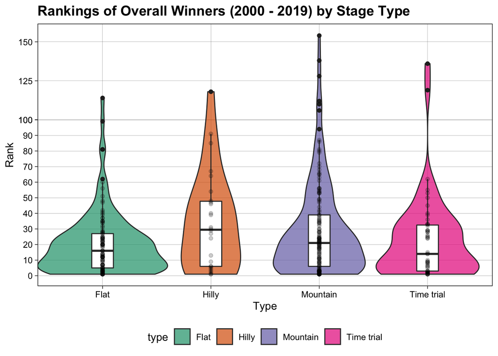

Figure 6.4: Rankings of Overall Winners (2000 - 2019) by Stage Type

Given the length of the tour and the different terrains, the fastest rider does not win Tour De France, but a more game theoretical approach Prinz and Wicker (2012). Figure 6.4 illustrates that overall winners are versatile riders with an itinerary that necessitates different strategies for the various stage types. This is also manifest in table 6.1, which establishes that overall winners are ranked 5 and below in approximately 7 in 10 races for all types of stage. Notably, the Figure (6.4) also reinforces the idea that overall winners does not always perform great in all stages, as seen with the variability of ranks at each type of stage.

Secondly, constantly winning team trial tests convey that a great team is a significant driver for winning the stage. A strategic reality is that the speediest individual will most likely not surpass a group of cyclists as the perfect sprints are often a result of seamless teamwork and aerodynamic advantages (Prinz and Wicker (2012)). This is especially complex as teams must find an ideal pace despite their diverse body types and skills. For instance, team’s *domestiques* (French for servants) work in unison to allow for drafting (shield from wind resistance by riders in front) to facilitate a smoother ride for the team leader (Allain (2018)). This can ensure he arrives at crucial moments of the race with little energy expended.

## 6.5 Conclusion

Each year, tour organisers vary the stages for the course differently, where each stage type requires a different tactic. Overall winners does not triumph without his team to allow him to take advantage of aerodynamics to ride at higher speeds with less energy exhausted, to preserve his energy for critical stages.

## Should we add these?

Allain, Rhett. 2018. “The Physics of Drafting in the Tour de France.” 2018. https://www.wired.com/story/the-physics-of-drafting-in-the-tour-de-france/.

Andreff, Wladimir. 2016. “The Tour de France: A Success Story in Spite of Competitive Imbalance and Doping.” In *The Economics of Professional Road Cycling*, 233–55. Springer.

Faulkner, Steve, and Katy Griggs. 2016. “How Does a Tour de France Favourite Win on the Scorching Mountain Slopes?” 2016. https://theconversation.com/how-does-a-tour-de-france-favourite-win-on-the-scorching-mountain-slopes-61316.

M, Mitchell. 2017. “Champs Elysees = the Most Iconic Street in Cycling.” 2017. https://www.procyclinguk.com/champs-elysees/.

Prinz, Joachim, and Pamela Wicker. 2012. “Team and Individual Performance in the Tour de France.” *Team Performance Management: An International Journal* 18 (7/8): 418–32.

Santalla, Alfredo, Conrad P Earnest, José A Marroyo, and Alejandro Lucia. 2012. “The Tour de France: An Updated Physiological Review.” *International Journal of Sports Physiology and Performance* 7 (3): 200–209.

Vogt, Stefan, Yorck Olaf Schumacher, Andreas Blum, Kai Roecker, Hans-Hermann Dickhuth, Andreas Schmid, and Lothar Heinrich. 2007. “Cycling Power Output Produced During Flat and Mountain Stages in the Giro d’Italia: A Case Study.” *Journal of Sports Sciences* 25 (12): 1299–1305.

Wikipedia contributors. 2020. “2018 Tour de France — Wikipedia, the Free Encyclopedia.” https://en.wikipedia.org/w/index.php?title=2018_Tour_de_France&oldid=960595512.

Wikipedia contributors. 2020. “2019 Tour de France — Wikipedia, the Free Encyclopedia.” https://en.wikipedia.org/w/index.php?title=2019_Tour_de_France&oldid=968463007.